# PLAY Survey Data

Rick Gilmore

2021-02-25 13:49:11

# Purpose

This document shows how to access and visualize survey response data from the PLAY dataset.

# Rendering

To render the document, issue this command from the R console

`rmarkdown::render('survey-data.Rmd', params = list(db_login='<YOUR_DATABRARY_LOGIN>'))`

substituting your actual Databrary login (email account) for `<YOUR_DATABRARY_LOGIN>`.

If you try to ‘knit’ the document another way, it won’t work.

# Setup

There are several R packages we need to run this code. The following will test to see if the packages are installed on your system. If not, the packages will be installed for you.

```r
knitr::opts_chunk$set(echo = TRUE)

if (!require(tidyverse)) {
  install.packages('tidyverse')
}

if (!require(devtools)) {
  install.packages('devtools')
}

if (!require(databraryapi)) {
  devtools::install_github('PLAY-behaviorome/databraryapi')
}

library(tidyverse) # for pipe `%>%` operator
```

You will need to login to Databrary in order to access the PLAY data. The next chunk asks for your Databrary credentials. It returns `TRUE` if your login is successful.

```r
databraryapi::login_db(params$db_login)
```

```
## Login successful.
```

```
## [1] TRUE
```

# List files

Databrary 1.0 has a volume/session structure. A volume is a dataset or collection. A session is a collection of related files. You can think of a session as a folder. The survey data are in a session folder called ‘KoBoToolbox Survey Data’. Volumes and sessions have ID numbers that Databrary uses to access each.

The PLAY data release volume has an id of 1280. The survey data session has a session id of 51539.

So, to go to the PLAY volume in your browser, you can visit https://nyu.databrary.org/volume/1280.

The following code, however, does all of this within an R session.

```r
play_survey_files <-
  databraryapi::list_assets_in_session(session_id = params$play_survey_session_id)

# Print the files data in a 'pretty' way
play_survey_files %>%
  kableExtra::kbl(.) %>%
  kableExtra::kable_styling(., bootstrap_options = c("striped", "hover", "condensed", "responsive")) %>%
  kableExtra::scroll_box(width = "800px", height = "300px")
```

| asset_id | asset_type_id | classification | name | permission | size | session_id | mimetype | extension | asset_type | transcodable |
| --- | --- | --- | --- | --- | --- | --- | --- | --- | --- | --- |
| 301691 | 2 | 1 | PLAY_all_loco_milestones | 5 | 15586 | 51539 | text/csv | csv | Comma-separated values | NA |
| 297665 | 2 | 1 | PLAY_all_basic_demog | 5 | 4860 | 51539 | text/csv | csv | Comma-separated values | NA |
| 297528 | 2 | 1 | PLAY_all_ecbq | 5 | 21167 | 51539 | text/csv | csv | Comma-separated values | NA |
| 297529 | 2 | 1 | PLAY_all_health | 5 | 14726 | 51539 | text/csv | csv | Comma-separated values | NA |
| 297525 | 2 | 1 | PLAY_all_demog_quest | 5 | 35437 | 51539 | text/csv | csv | Comma-separated values | NA |
| 297527 | 2 | 1 | PLAY_all_pets | 5 | 1963 | 51539 | text/csv | csv | Comma-separated values | NA |
| 297526 | 2 | 1 | PLAY_all_household_labor | 5 | 13560 | 51539 | text/csv | csv | Comma-separated values | NA |
| 297524 | 2 | 1 | PLAY_all_typical_day | 5 | 3170 | 51539 | text/csv | csv | Comma-separated values | NA |
| 297522 | 2 | 1 | PLAY_all_media | 5 | 9108 | 51539 | text/csv | csv | Comma-separated values | NA |

Note that each file has an `asset_id`. We’ll use this to access the data file(s) we want.

# Import by measure

## Pets

```r
# Grab the asset_id for the pets data based on the name
pets_in_name <- stringr::str_detect(play_survey_files$name, 'pets')
pets_asset_id <- play_survey_files$asset_id[pets_in_name]

# Select and download the pets data
pets <-
  databraryapi::read_csv_data_as_df(params$play_survey_session_id, as.numeric(pets_asset_id))

# Print the pets data
pets %>%
  kableExtra::kbl(.) %>%
  kableExtra::kable_styling(., bootstrap_options = c("striped", "hover", "condensed", "responsive")) %>%
  kableExtra::scroll_box(width = "800px", height = "300px")
```

| play_site_id | site_child_id | child_age_grp | child_sex | kobo_form | pets_at_home | type_number | where_live | pets_comments |
| --- | --- | --- | --- | --- | --- | --- | --- | --- |
| PLAY_89941455 | 3 | 12 month | Female | 12_Bilingual_English | No | NA | NA | NA |
| PLAY_89941534 | 1 | 12 month | Female | 12_Bilingual_Spanish | Sí | Dog | Adentro | NA |
| PLAY_899_232_NODB | 232 | 12 month | Female | 12_English | Yes | Dog 1 | Indoors | NA |
| PLAY_89941894 | 7 | 12 month | Female | 12_English | Yes | 2 cats | Indoors | NA |
| PLAY_95442353 | 10 | 12 month | Male | 12_English | No | NA | NA | NA |
| PLAY_95441417 | 3 | 12 month | Female | 12_English | No | NA | NA | NA |
| PLAY_89943207 | 13 | 12 month | Female | 12_English | Yes | Cats (2) | Indoors | NA |
| PLAY_899_226_NODB | 226 | 12 month | Male | 12_English | No | NA | NA | NA |
| PLAY_89938197 | 228 | 12 month | Male | 12_English | No | NA | NA | NA |
| PLAY_89938485 | 231 | 12 month | Female | 12_English | No | NA | NA | NA |
| PLAY_95441428 | 4 | 12 month | Female | 12_English | No | NA | NA | NA |
| PLAY_89941608 | 5 | 12 month | Female | 12_English | Yes | Dogs (2) | Indoors | NA |
| PLAY_95442694 | 11 | 18 month | male | 18_English | Yes | dog 1 | Indoors | NA |
| PLAY_95442127 | 8 | 18 month | female | 18_English | Yes | Cat 1 | Indoors | NA |
| PLAY_98242940 | 3 | 18 month | male | 18_English | Yes | 1 cat | Indoors | NA |
| PLAY_89938196 | 227 | 18 month | female | 18_English | No | NA | NA | NA |
| PLAY_95440510 | 2 | 18 month | female | 18_English | Yes | Dog (1) | Indoors | NA |
| PLAY_899_232_NODB | 232 | 18 month | male | 18_English | Yes | Dog (1) | Indoors | NA |
| PLAY_89941535 | 4 | 18 month | male | 18_English | No | NA | NA | NA |
| PLAY_96643624 | 1 | 18 month | male | 18_English | No | NA | NA | NA |
| PLAY_110344638 | 1 | 18 month | female | 18_English | No | NA | NA | NA |
| PLAY_89938215 | 229 | 24 month | Female | 24_Bilingual_Spanish | No | NA | NA | NA |
| PLAY_98242292 | 2 | 24 month | female | 24_English | Yes | 1dog | Indoors | Split between indoors and outdoors |
| PLAY_95442353 | 10 | 24 month | female | 24_English | No | NA | NA | NA |
| PLAY_95441873 | 5 | 24 month | male | 24_English | Yes | Dog | Indoors | NA |
| PLAY_89938236 | 230 | 24 month | male | 24_English | Yes | 1 Dog | Indoors | NA |
| PLAY_89941800 | 2 | 24 month | male | 24_English | No | NA | NA | NA |
| PLAY_89941808 | 6 | 24 month | male | 24_English | No | NA | NA | NA |
| PLAY_95441873 | 5 | 24 month | male | 24_English | Yes | Dog (1) | Indoors | NA |
| PLAY_89943530 | 14 | 24 month | male | 24_English | No | NA | NA | NA |

We can do a bit of clean-up here to see what families have pets and of what type.

```r
pets_cleaned <- pets %>%
  dplyr::mutate(., pets_at_home = recode(pets_at_home, 'Sí' = 'Yes'),
                has_dog = stringr::str_detect(type_number, '[dD]og'),
                has_cat = stringr::str_detect(type_number, '[cC]at'),
                where_live = recode(where_live, 'Adentro' = 'Indoors')) %>%
  dplyr::arrange(., child_age_grp)
```

### Homes with dogs

```r
pets_cleaned %>%
  dplyr::filter(., has_dog == TRUE) %>%
  kableExtra::kbl(.) %>%
  kableExtra::kable_styling(., bootstrap_options = c("striped", "hover", "condensed", "responsive")) %>%
  kableExtra::scroll_box(width = "800px", height = "300px")
```

| play_site_id | site_child_id | child_age_grp | child_sex | kobo_form | pets_at_home | type_number | where_live | pets_comments | has_dog | has_cat |
| --- | --- | --- | --- | --- | --- | --- | --- | --- | --- | --- |
| PLAY_89941534 | 1 | 12 month | Female | 12_Bilingual_Spanish | Yes | Dog | Indoors | NA | TRUE | FALSE |
| PLAY_899_232_NODB | 232 | 12 month | Female | 12_English | Yes | Dog 1 | Indoors | NA | TRUE | FALSE |
| PLAY_89941608 | 5 | 12 month | Female | 12_English | Yes | Dogs (2) | Indoors | NA | TRUE | FALSE |
| PLAY_95442694 | 11 | 18 month | male | 18_English | Yes | dog 1 | Indoors | NA | TRUE | FALSE |
| PLAY_95440510 | 2 | 18 month | female | 18_English | Yes | Dog (1) | Indoors | NA | TRUE | FALSE |
| PLAY_899_232_NODB | 232 | 18 month | male | 18_English | Yes | Dog (1) | Indoors | NA | TRUE | FALSE |
| PLAY_98242292 | 2 | 24 month | female | 24_English | Yes | 1dog | Indoors | Split between indoors and outdoors | TRUE | FALSE |
| PLAY_95441873 | 5 | 24 month | male | 24_English | Yes | Dog | Indoors | NA | TRUE | FALSE |
| PLAY_89938236 | 230 | 24 month | male | 24_English | Yes | 1 Dog | Indoors | NA | TRUE | FALSE |
| PLAY_95441873 | 5 | 24 month | male | 24_English | Yes | Dog (1) | Indoors | NA | TRUE | FALSE |

It looks like there are more homes with dogs.

### Homes with cats

```r
pets_cleaned %>%
  dplyr::filter(., has_cat == TRUE) %>%
  kableExtra::kbl(.) %>%
  kableExtra::kable_styling(., bootstrap_options = c("striped", "hover", "condensed", "responsive")) %>%
  kableExtra::scroll_box(width = "800px", height = "300px")
```

| play_site_id | site_child_id | child_age_grp | child_sex | kobo_form | pets_at_home | type_number | where_live | pets_comments | has_dog | has_cat |
| --- | --- | --- | --- | --- | --- | --- | --- | --- | --- | --- |
| PLAY_89941894 | 7 | 12 month | Female | 12_English | Yes | 2 cats | Indoors | NA | FALSE | TRUE |
| PLAY_89943207 | 13 | 12 month | Female | 12_English | Yes | Cats (2) | Indoors | NA | FALSE | TRUE |
| PLAY_95442127 | 8 | 18 month | female | 18_English | Yes | Cat 1 | Indoors | NA | FALSE | TRUE |
| PLAY_98242940 | 3 | 18 month | male | 18_English | Yes | 1 cat | Indoors | NA | FALSE | TRUE |

Most cats and dogs live indoors. This must be in NYC!

Also, there seem to be dog families and cat families, but not both.

## Typical day

```r
# Grab the asset_id for the data based on the name
typical_in_name <-
  stringr::str_detect(play_survey_files$name, 'typical')
typical_asset_id <- play_survey_files$asset_id[typical_in_name]

# Select and download the data
typical_day_data <-
  databraryapi::read_csv_data_as_df(params$play_survey_session_id, as.numeric(typical_asset_id))

# Print the data
typical_day_data %>%
  kableExtra::kbl(.) %>%
  kableExtra::kable_styling(.,
                            bootstrap_options = c("striped", "hover", "condensed", "responsive")) %>%
  kableExtra::scroll_box(width = "800px", height = "300px")
```

| play_site_id | site_child_id | child_age_grp | child_sex | kobo_form | typical_day | day_how_different | activities_similar | activities_different | typical_night_morning | night_morning_how_different | unusual_feelings | feelings_how_different |
| --- | --- | --- | --- | --- | --- | --- | --- | --- | --- | --- | --- | --- |
| PLAY_89941455 | 3 | 12 month | Female | 12_Bilingual_English | Yes | NA | Yes | NA | Yes | NA | Yes | NA |
| PLAY_89941534 | 1 | 12 month | Female | 12_Bilingual_Spanish | Sí | NA | Sí | NA | Sí | NA | Sí | NA |
| PLAY_899_232_NODB | 232 | 12 month | Female | 12_English | Yes | NA | Yes | NA | Yes | NA | Yes | NA |
| PLAY_89941894 | 7 | 12 month | Female | 12_English | NA | NA | NA | NA | NA | NA | NA | NA |
| PLAY_95442353 | 10 | 12 month | Male | 12_English | Yes | NA | Yes | NA | Yes | NA | Yes | NA |
| PLAY_95441417 | 3 | 12 month | Female | 12_English | Yes | NA | Yes | NA | Yes | NA | No | Mom had a “debilitating cold” |
| PLAY_89943207 | 13 | 12 month | Female | 12_English | Yes | NA | Yes | NA | Yes | NA | No | Mom would typically be at work |
| PLAY_899_226_NODB | 226 | 12 month | Male | 12_English | Yes | NA | Yes | NA | Yes | NA | No | Child took a nap before experimenter came. |
| PLAY_89938197 | 228 | 12 month | Male | 12_English | Yes | NA | Yes | NA | Yes | NA | Yes | NA |
| PLAY_89938485 | 231 | 12 month | Female | 12_English | Yes | NA | Yes | NA | No | She was at a friend’s for the night first and then brought home. She slept about the same but slept in a little bit more. | Yes | NA |
| PLAY_95441428 | 4 | 12 month | Female | 12_English | Yes | NA | Yes | NA | Yes | NA | No | Spent less time with nanny |
| PLAY_89941608 | 5 | 12 month | Female | 12_English | Yes | NA | Yes | NA | No | Baby up last night and didn’t sleep well. Baby slept in this morning, timing of usual routine is off. | Yes | NA |
| PLAY_95442694 | 11 | 18 month | male | 18_English | Yes | NA | No | Stayed indoors | Yes | NA | Yes | NA |
| PLAY_95442127 | 8 | 18 month | female | 18_English | Yes | NA | Yes | NA | Yes | NA | Yes | NA |
| PLAY_98242940 | 3 | 18 month | male | 18_English | Yes | NA | Yes | NA | Yes | NA | Yes | NA |
| PLAY_89938196 | 227 | 18 month | female | 18_English | Yes | NA | Yes | NA | Yes | NA | Yes | NA |
| PLAY_95440510 | 2 | 18 month | female | 18_English | Yes | NA | Yes | NA | Yes | NA | Yes | NA |
| PLAY_899_232_NODB | 232 | 18 month | male | 18_English | Yes | NA | Yes | NA | Yes | NA | Yes | NA |
| PLAY_89941535 | 4 | 18 month | male | 18_English | No | Crankier than usual | No | Usually go outside | No | Wasn’t sleeping well. Woke up at 2am and then again earlier than usual | No | Mom was more tired and stressed than usual. |
| PLAY_96643624 | 1 | 18 month | male | 18_English | Yes | NA | Yes | NA | Yes | NA | Yes | NA |
| PLAY_110344638 | 1 | 18 month | female | 18_English | No | A little more shy than normal, and usually follows mom, but has a new toy (stickers) and wanted to focus on that today | No | Yes because it was raining, but if it was not raining this is the time of day that they normally go outside | Yes | NA | Yes | NA |
| PLAY_89938215 | 229 | 24 month | Female | 24_Bilingual_Spanish | Sí | NA | Sí | NA | Sí | NA | Sí | NA |
| PLAY_98242292 | 2 | 24 month | female | 24_English | Yes | NA | Yes | NA | Yes | NA | Yes | NA |
| PLAY_95442353 | 10 | 24 month | female | 24_English | Yes | NA | Yes | NA | Yes | NA | Yes | NA |
| PLAY_95441873 | 5 | 24 month | male | 24_English | Yes | NA | Yes | NA | Yes | NA | Yes | NA |
| PLAY_89938236 | 230 | 24 month | male | 24_English | Yes | NA | Yes | NA | Yes | NA | No | Dog having to go out early |
| PLAY_89941800 | 2 | 24 month | male | 24_English | Yes | NA | Yes | NA | No | Got home a little later so different bedtime routine | Yes | NA |
| PLAY_89941808 | 6 | 24 month | male | 24_English | Yes | NA | Yes | NA | Yes | NA | Yes | NA |
| PLAY_95441873 | 5 | 24 month | male | 24_English | Yes | NA | Yes | NA | Yes | NA | Yes | NA |
| PLAY_89943530 | 14 | 24 month | male | 24_English | Yes | NA | Yes | NA | Yes | NA | Yes | NA |

We’ll do a little clean-up and select a smaller number of columns.

```r
typical_cleaned <- typical_day_data %>%
  dplyr::mutate(
    .,
    typical_day = recode(typical_day, 'Sí' = 'Yes'),
    activities_similar = recode(activities_similar, 'Sí' = 'Yes'),
    typical_night_morning = recode(typical_night_morning, 'Sí' = 'Yes'),
    unusual_feelings = recode(unusual_feelings, 'Sí' = 'Yes')
  ) %>%
  dplyr::select(
    .,
    play_site_id,
    child_age_grp,
    typical_day,
    activities_similar,
    typical_night_morning,
    unusual_feelings
  ) %>%
  dplyr::arrange(., child_age_grp)

# Print the data
typical_cleaned %>%
  kableExtra::kbl(.) %>%
  kableExtra::kable_styling(.,
                            bootstrap_options = c("striped", "hover", "condensed", "responsive")) %>%
  kableExtra::scroll_box(width = "800px", height = "300px")
```

| play_site_id | child_age_grp | typical_day | activities_similar | typical_night_morning | unusual_feelings |
| --- | --- | --- | --- | --- | --- |
| PLAY_89941455 | 12 month | Yes | Yes | Yes | Yes |
| PLAY_89941534 | 12 month | Yes | Yes | Yes | Yes |
| PLAY_899_232_NODB | 12 month | Yes | Yes | Yes | Yes |
| PLAY_89941894 | 12 month | NA | NA | NA | NA |
| PLAY_95442353 | 12 month | Yes | Yes | Yes | Yes |
| PLAY_95441417 | 12 month | Yes | Yes | Yes | No |
| PLAY_89943207 | 12 month | Yes | Yes | Yes | No |
| PLAY_899_226_NODB | 12 month | Yes | Yes | Yes | No |
| PLAY_89938197 | 12 month | Yes | Yes | Yes | Yes |
| PLAY_89938485 | 12 month | Yes | Yes | No | Yes |
| PLAY_95441428 | 12 month | Yes | Yes | Yes | No |
| PLAY_89941608 | 12 month | Yes | Yes | No | Yes |
| PLAY_95442694 | 18 month | Yes | No | Yes | Yes |
| PLAY_95442127 | 18 month | Yes | Yes | Yes | Yes |
| PLAY_98242940 | 18 month | Yes | Yes | Yes | Yes |
| PLAY_89938196 | 18 month | Yes | Yes | Yes | Yes |
| PLAY_95440510 | 18 month | Yes | Yes | Yes | Yes |
| PLAY_899_232_NODB | 18 month | Yes | Yes | Yes | Yes |
| PLAY_89941535 | 18 month | No | No | No | No |
| PLAY_96643624 | 18 month | Yes | Yes | Yes | Yes |
| PLAY_110344638 | 18 month | No | No | Yes | Yes |
| PLAY_89938215 | 24 month | Yes | Yes | Yes | Yes |
| PLAY_98242292 | 24 month | Yes | Yes | Yes | Yes |
| PLAY_95442353 | 24 month | Yes | Yes | Yes | Yes |
| PLAY_95441873 | 24 month | Yes | Yes | Yes | Yes |
| PLAY_89938236 | 24 month | Yes | Yes | Yes | No |
| PLAY_89941800 | 24 month | Yes | Yes | No | Yes |
| PLAY_89941808 | 24 month | Yes | Yes | Yes | Yes |
| PLAY_95441873 | 24 month | Yes | Yes | Yes | Yes |
| PLAY_89943530 | 24 month | Yes | Yes | Yes | Yes |

Note that the `unusual_feelings` variable might need to be examined more closely. This short name might not reflect the actual question properly.

```r
typical_day %>%
  dplyr::select(., child_age_grp, typical_day) %>%
  dplyr::filter(., !is.na(typical_day)) %>%
  dplyr::mutate(., typical_day = recode(typical_day, 'Sí' = 'Yes')) %>%
  dplyr::group_by(child_age_grp) %>%
  dplyr::summarise(n_families = n(),
                   n_rating_typical = sum(typical_day == 'Yes')) %>%
  kableExtra::kbl(.) %>%
  kableExtra::kable_styling(.,
                            bootstrap_options = c("striped", "hover", "condensed", "responsive")) %>%
  kableExtra::scroll_box(width = "800px", height = "250px")
```

| child_age_grp | n_families | n_rating_typical |
| --- | --- | --- |
| 12 month | 11 | 11 |
| 18 month | 9 | 7 |
| 24 month | 9 | 9 |

## Household labor

```r
# Grab the asset_id for the data based on the name
labor_in_name <-
  stringr::str_detect(play_survey_files$name, 'labor')
household_labor_asset_id <- play_survey_files$asset_id[labor_in_name]

# Select and download the data
household_labor <-
  databraryapi::read_csv_data_as_df(params$play_survey_session_id, as.numeric(household_labor_asset_id))

# Print the data
household_labor %>%
  kableExtra::kbl(.) %>%
  kableExtra::kable_styling(.,
                            bootstrap_options = c("striped", "hover", "condensed", "responsive")) %>%
  kableExtra::scroll_box(width = "800px", height = "300px")
```

| play_site_id | site_child_id | child_age_grp | child_sex | kobo_form | laundry_caregiver | laundry_partner | laundry_other | laundry_who_else | cleaning_caregiver | cleaning_partner | cleaning_other | cleaning_who_else | dishes_caregiver | dishes_partner | dishes_other | dishes_who_else | cooking_caregiver | cooking_partner | cooking_other | cooking_who_else | feed_child_caregiver | feed_child_partner | feed_child_other | feed_child_who_else | dropoff_child_caregiver | dropoff_child_partner | dropoff_child_other | dropoff_child_who_else | to_bed_child_caregiver | … |
| --- | --- | --- | --- | --- | --- | --- | --- | --- | --- | --- | --- | --- | --- | --- | --- | --- | --- | --- | --- | --- | --- | --- | --- | --- | --- | --- | --- | --- | --- | --- |
| PLAY_89941455 | 3 | 12 month | Female | 12_Bilingual_English | 4 - All of it | 0 - None | NA | NA | 2 - About half of it | 2 - About half of it | NA | NA | 3 - Most of it | 1 - Some of it | NA | NA | 3 - Most of it | 0 - None | NA | NA | 3 - Most of the time | 1 - Some of the time | NA | NA | Does not apply | Does not apply | NA | NA | 3 - Most of the time | … |
| PLAY_89941534 | 1 | 12 month | Female | 12_Bilingual_Spanish | 2 - Alrededor de la mitad | 2 - Alrededor de la mitad | 1 - Algo | Helo | NA | NA | NA | NA | 2 - Alrededor de la mitad | 2 - Alrededor de la mitad | NA | NA | 1 - Algo | 3 - La mayoría | NA | NA | 1 - Algunas veces | 3 - La mayoría de las veces | NA | NA | 1 - Algunas veces | 4 - Todas las veces | NA | NA | 3 - La mayoría de las veces | … |
| PLAY_899_232_NODB | 232 | 12 month | Female | 12_English | 3 - Most of it | 1 - Some of it | 1 - Some of it | Nanny does bab’sy laundry | 3 - Most of it | 1 - Some of it | 2 - About half of it | Cleaning lady, and nanny | 3 - Most of it | 1 - Some of it | 2 - About half of it | Cleaning lady and nanny | 2 - About half of it | 1 - Some of it | 1 - Some of it | Nanny | 2 - About half of the time | 1 - Some of the time | 2 - About half of the time | Nanny | Does not apply | Does not apply | Does not apply | NA | 4 - All the time | … |
| PLAY_89941894 | 7 | 12 month | Female | 12_English | 2 - About half of it | 2 - About half of it | NA | NA | 2 - About half of it | 2 - About half of it | NA | NA | 2 - About half of it | 2 - About half of it | NA | NA | 2 - About half of it | 2 - About half of it | NA | NA | 3 - Most of the time | 2 - About half of the time | 1 - Some of the time | babysitter | Does not apply | Does not apply | NA | NA | 2 - About half of the time | … |
| PLAY_95442353 | 10 | 12 month | Male | 12_English | All of it | None | None | NA | About half of it | About half of it | Some | NA | About half of it | About half of it | None | NA | Some of it | Most of it | None | NA | Most of the time | Some of the time | Some of the time | Daycare and grandparents | Most of the time | Some of the time | Some of the time | NA | Most of the time | … |
| PLAY_95441417 | 3 | 12 month | Female | 12_English | All of it | Some of it | None | NA | Most of it | None | Some | Housekeeper, no relation to Zora | Most of it | Some of it | None | NA | Most of it | Some of it | None | NA | Most of the time | About half of the time | Never | NA | Does not apply | Does not apply | Does not apply | NA | All the time | … |
| PLAY_89943207 | 13 | 12 month | Female | 12_English | 3 - Most of it | 1 - Some of it | 1 - Some of it | Nanny | 1 - Some of it | 1 - Some of it | 3 - Most of it | Housecleaner | 3 - Most of it | 2 - About half of it | 1 - Some of it | Nanny | 3 - Most of it | 2 - About half of it | NA | NA | 3 - Most of the time | 2 - About half of the time | 3 - Most of the time | Nanny | Does not apply | Does not apply | NA | NA | 4 - All the time | … |
| PLAY_899_226_NODB | 226 | 12 month | Male | 12_English | About half of it | None | About half of it | Sends it out and has weekly housekeeper do it. | About half of it | None | About half of it | Housekeeper | All of it | None | NA | NA | All of it | None | NA | NA | All the time | Never | Most of the time | Grandmother or cousin | Does not apply | Does not apply | Does not apply | NA | About half of the time | … |
| PLAY_89938197 | 228 | 12 month | Male | 12_English | All of it | None | NA | NA | Some | None | NA | NA | All of it | Some of it | NA | NA | About half of it | About half of it | NA | NA | About half of the time | About half of the time | NA | NA | All the time | Never | NA | NA | About half of the time | … |
| PLAY_89938485 | 231 | 12 month | Female | 12_English | Some of it | Some of it | Most of it | Nanny | About half of it | About half of it | Some | Nanny | Some of it | Most of it | Most of it | Nanny | Some of it | Some of it | Some of it | Nanny | Some of the time | Some of the time | About half of the time | Nanny | Does not apply | Does not apply | NA | NA | About half of the time | … |
| PLAY_95441428 | 4 | 12 month | Female | 12_English | Most of it | Some of it | NA | NA | Some | Some | About half of it | NA | All of it | NA | NA | NA | Some of it | All of it | NA | NA | Most of the time | Some of the time | Some of the time | Nanny | All the time | All the time | NA | NA | Most of the time | … |
| PLAY_89941608 | 5 | 12 month | Female | 12_English | About half of it | Some of it | NA | NA | About half of it | Some | NA | NA | Some of it | Some of it | NA | NA | About half of it | Some of it | NA | NA | About half of the time | Some of the time | NA | NA | Does not apply | Does not apply | NA | NA | Most of the time | … |
| PLAY_95442694 | 11 | 18 month | male | 18_English | Most of it | Some of it | None | NA | About half of it | About half of it | Some | Cleaning lady | About half of it | About half of it | None | NA | About half of it | About half of it | None | NA | About half of the time | About half of the time | Never | NA | About half of the time | About half of the time | Some of the time | Grandmother | About half of the time | … |
| PLAY_95442127 | 8 | 18 month | female | 18_English | Some of it | Most of it | None | NA | Some | Most of it | None | NA | Some of it | Most of it | None | NA | Most of it | Some of it | None | NA | About half of the time | About half of the time | Some of the time | Grandmother | Does not apply | Does not apply | Never | NA | About half of the time | … |
| PLAY_98242940 | 3 | 18 month | male | 18_English | 2 - About half of it | 2 - About half of it | 0 - None | NA | 2 - About half of it | 2 - About half of it | 0 - None | NA | 2 - About half of it | 2 - About half of it | 0 - None | NA | 3 - Most of it | 1 - Some of it | 0 - None | NA | 2 - About half of the time | 2 - About half of the time | 1 - Some of the time | Day care or grandparent for lunch | 2 - About half of the time | 2 - About half of the time | 0 - Never | NA | 2 - About half of the time | … |
| PLAY_89938196 | 227 | 18 month | female | 18_English | Most of it | Some of it | NA | NA | Some | None | Most of it | Housecleaner who comes every other week | All of it | None | NA | NA | All of it | None | NA | NA | Most of the time | Some of the time | NA | NA | Does not apply | Does not apply | NA | NA | All the time | … |
| PLAY_95440510 | 2 | 18 month | female | 18_English | About half of it | About half of it | NA | NA | Some | Most of it | NA | NA | Some of it | Most of it | NA | NA | About half of it | About half of it | NA | NA | Most of the time | Some of the time | NA | NA | About half of the time | About half of the time | NA | NA | Most of the time | … |
| PLAY_899_232_NODB | 232 | 18 month | male | 18_English | All of it | None | NA | NA | All of it | None | NA | NA | Most of it | Some of it | NA | NA | Some of it | Most of it | NA | NA | About half of the time | About half of the time | NA | NA | Most of the time | Some of the time | NA | NA | All the time | … |
| PLAY_89941535 | 4 | 18 month | male | 18_English | About half of it | Some of it | Some of it | Nanny | Some | None | Most of it | Cleaning lady | About half of it | None | About half of it | Nanny | Some of it | Some of it | Some of it | Nanny | Some of the time | Some of the time | Most of the time | Nanny | Does not apply | Does not apply | NA | NA | About half of the time | … |
| PLAY_96643624 | 1 | 18 month | male | 18_English | 0 - None | 4 - All of it | NA | NA | 1 - Some of it | 3 - Most of it | 1 - Some of it | Cleaning person comes once a month. | 1 - Some of it | 3 - Most of it | NA | NA | 1 - Some of it | 3 - Most of it | NA | NA | 2 - About half of the time | 2 - About half of the time | 1 - Some of the time | At daycare or grandparents | 1 - Some of the time | 3 - Most of the time | NA | NA | 3 - Most of the time | … |
| PLAY_110344638 | 1 | 18 month | female | 18_English | 3 - Most of it | 1 - Some of it | NA | NA | 2 - About half of it | 2 - About half of it | 1 - Some of it | Cleaner for the bathrooms (hired - no relationship to Aliana) | 2 - About half of it | 2 - About half of it | NA | NA | 2 - About half of it | 2 - About half of it | NA | NA | 4 - All the time | 1 - Some of the time | 1 - Some of the time | Babysitter (friend) feeds her snacks (goes to babysitter 2.5 hours twice a week) | 4 - All the time | 0 - Never | NA | NA | 2 - About half of the time | … |
| PLAY_89938215 | 229 | 24 month | Female | 24_Bilingual_Spanish | Alrededor de la mitad | Alrededor de la mitad | Nada | NA | Alrededor de la mitad | Alrededor de la mitad | Algo | NA | La mayoría | Algo | Nada | NA | Alrededor de la mitad | Algo | Nada | NA | Todas las veces | Algunas veces | Nunca | NA | Todas las veces | Nunca | Nunca | NA | Todas las veces | … |
| PLAY_98242292 | 2 | 24 month | female | 24_English | About half of it | About half of it | None | NA | About half of it | About half of it | None | NA | About half of it | About half of it | None | NA | About half of it | About half of it | None | NA | Most of the time | Some of the time | Never | NA | Most of the time | Most of the time | Never | NA | Most of the time | … |
| PLAY_95442353 | 10 | 24 month | female | 24_English | All of it | Some of it | None | NA | About half of it | About half of it | About half of it | NA | About half of it | About half of it | None | NA | All of it | Some of it | None | NA | About half of the time | About half of the time | Never | NA | Most of the time | All the time | Never | NA | About half of the time | … |
| PLAY_95441873 | 5 | 24 month | male | 24_English | Most of it | Some of it | None | NA | About half of it | About half of it | None | NA | About half of it | About half of it | NA | NA | All of it | Some of it | NA | NA | All the time | Some of the time | NA | NA | About half of the time | About half of the time | NA | NA | Some of the time | … |
| PLAY_89938236 | 230 | 24 month | male | 24_English | All of it | None | None | NA | About half of it | About half of it | Some | Custodian comes in every other month to do overall cleaning | None | All of it | None | NA | All of it | None | None | NA | About half of the time | About half of the time | Some of the time | Day care | About half of the time | About half of the time | Never | NA | Some of the time | … |
| PLAY_89941800 | 2 | 24 month | male | 24_English | None | Some of it | Most of it | Laundromat | Some | Some | Some | Cleaning person | About half of it | About half of it | NA | NA | About half of it | About half of it | NA | NA | Most of the time | Some of the time | About half of the time | Daycare staff | About half of the time | About half of the time | NA | NA | Most of the time | … |
| PLAY_89941808 | 6 | 24 month | male | 24_English | All of it | None | NA | NA | All of it | Some | About half of it | House cleaner | All of it | Some of it | NA | NA | Most of it | Some of it | NA | NA | Most of the time | Some of the time | Some of the time | At school, mom’s sister | All the time | Never | NA | NA | Most of the time | … |
| PLAY_95441873 | 5 | 24 month | male | 24_English | Most of it | Some of it | NA | NA | About half of it | About half of it | NA | NA | About half of it | About half of it | NA | NA | All of it | Some of it | NA | NA | All the time | Some of the time | NA | NA | About half of the time | About half of the time | NA | NA | Some of the time | … |
| PLAY_89943530 | 14 | 24 month | male | 24_English | 2 - About half of it | 2 - About half of it | NA | NA | 2 - About half of it | 2 - About half of it | NA | NA | 2 - About half of it | 2 - About half of it | NA | NA | 1 - Some of it | 3 - Most of it | NA | NA | 1 - Some of the time | 1 - Some of the time | 1 - Some of the time | Gets fed lunch at daycare. | 1 - Some of the time | 4 - All the time | NA | NA | 2 - About half of the time | … |

## Locomotor milestones

```r
# Grab the asset_id for the data based on the name
loco_in_name <-
  stringr::str_detect(play_survey_files$name, 'loco')
loco_milestones_asset_id <- play_survey_files$asset_id[loco_in_name]

# Select and download the data
loco_milestones <-
  databraryapi::read_csv_data_as_df(params$play_survey_session_id, as.numeric(loco_milestones_asset_id))

# Print the data
loco_milestones %>%
  # Drop comments here for privacy...
  dplyr::select(., -c('WHO_walk_comments', 'walk_onset_comments', 'crawl_onset_comments')) %>%
  kableExtra::kbl(.) %>%
  kableExtra::kable_styling(.,
                            bootstrap_options = c("striped", "hover", "condensed", "responsive")) %>%
  kableExtra::scroll_box(width = "800px", height = "300px")
```

| play_site_id | site_child_id | child_age_grp | child_sex | kobo_form | date_05mos | date_06mos | date_07mos | date_08mos | date_09mos | date_10mos | date_11mos | date_12mos | date_13mos | date_14mos | date_15mos | date_16mos | when_walk_5steps | WHO_walk_month | WHO_walk_age_mos | instr_5mos | instr_6mos | instr_7mos | instr_8mos | instr_9mos | instr_10mos | instr_11mos | instr_12mos | instr_13mos | instr_14mos | … |
| --- | --- | --- | --- | --- | --- | --- | --- | --- | --- | --- | --- | --- | --- | --- | --- | --- | --- | --- | --- | --- | --- | --- | --- | --- | --- | --- | --- | --- | --- | --- |
| PLAY_89941455 | 3 | 12 month | female | 12_Bilingual_English | 2019-03-13 (Wed Mar 13) | 2019-04-12 (Fri Apr 12) | 2019-05-12 (Sun May 12) | 2019-06-12 (Wed Jun 12) | 2019-07-12 (Fri Jul 12) | 2019-08-12 (Mon Aug 12) | 2019-09-11 (Wed Sep 11) | 2019-10-12 (Sat Oct 12) | 2019-11-11 (Mon Nov 11) | 2019-12-11 (Wed Dec 11) | 2020-01-11 (Sat Jan 11) | 2020-02-10 (Mon Feb 10) | NA | NaN | NA | NA | NA | NA | NA | NA | NA | NA | NA | NA | NA | … |
| PLAY_89941534 | 1 | 12 month | female | 12_Bilingual_Spanish | 2019-02-11 (Mon Feb 11) | 2019-03-13 (Wed Mar 13) | 2019-04-12 (Fri Apr 12) | 2019-05-13 (Mon May 13) | 2019-06-12 (Wed Jun 12) | 2019-07-13 (Sat Jul 13) | 2019-08-12 (Mon Aug 12) | 2019-09-12 (Thu Sep 12) | 2019-10-12 (Sat Oct 12) | 2019-11-11 (Mon Nov 11) | 2019-12-12 (Thu Dec 12) | 2020-01-11 (Sat Jan 11) | NA | NaN | NA | NA | NA | NA | NA | NA | NA | NA | NA | NA | NA | … |
| PLAY_899_232_NODB | 232 | 12 month | female | 12_English | 2019-03-10 (Sun Mar 10) | 2019-04-09 (Tue Apr 9) | 2019-05-09 (Thu May 9) | 2019-06-09 (Sun Jun 9) | 2019-07-09 (Tue Jul 9) | 2019-08-09 (Fri Aug 9) | 2019-09-08 (Sun Sep 8) | 2019-10-09 (Wed Oct 9) | 2019-11-08 (Fri Nov 8) | 2019-12-08 (Sun Dec 8) | 2020-01-08 (Wed Jan 8) | 2020-02-07 (Fri Feb 7) | 2019-09-15 | 11.21 | NA | NA | NA | NA | NA | NA | NA | NA | NA | NA | NA | … |
| PLAY_89941894 | 7 | 12 month | female | 12_English | 2019-04-12 (Fri Apr 12) | 2019-05-12 (Sun May 12) | 2019-06-11 (Tue Jun 11) | 2019-07-12 (Fri Jul 12) | 2019-08-11 (Sun Aug 11) | 2019-09-11 (Wed Sep 11) | 2019-10-11 (Fri Oct 11) | 2019-11-11 (Mon Nov 11) | 2019-12-11 (Wed Dec 11) | 2020-01-10 (Fri Jan 10) | 2020-02-10 (Mon Feb 10) | 2020-03-11 (Wed Mar 11) | 2019-10-29 | 11.57 | NA | NA | NA | NA | NA | NA | NA | NA | NA | NA | NA | … |
| PLAY_95442353 | 10 | 12 month | male | 12_English | 2019-06-06 (Thu Jun 6) | 2019-07-06 (Sat Jul 6) | 2019-08-05 (Mon Aug 5) | 2019-09-05 (Thu Sep 5) | 2019-10-05 (Sat Oct 5) | 2019-11-05 (Tue Nov 5) | 2019-12-05 (Thu Dec 5) | 2020-01-05 (Sun Jan 5) | 2020-02-04 (Tue Feb 4) | 2020-03-05 (Thu Mar 5) | 2020-04-05 (Sun Apr 5) | 2020-05-05 (Tue May 5) | NA | NaN | NA | NA | NA | NA | NA | NA | NA | NA | NA | NA | NA | … |
| PLAY_95441417 | 3 | 12 month | female | 12_English | 2019-03-10 (Sun Mar 10) | 2019-04-09 (Tue Apr 9) | 2019-05-09 (Thu May 9) | 2019-06-09 (Sun Jun 9) | 2019-07-09 (Tue Jul 9) | 2019-08-09 (Fri Aug 9) | 2019-09-08 (Sun Sep 8) | 2019-10-09 (Wed Oct 9) | 2019-11-08 (Fri Nov 8) | 2019-12-08 (Sun Dec 8) | 2020-01-08 (Wed Jan 8) | 2020-02-07 (Fri Feb 7) | NA | NaN | NA | NA | NA | NA | NA | NA | NA | NA | NA | NA | NA | … |
| PLAY_89943207 | 13 | 12 month | female | 12_English | 2019-07-29 (Mon Jul 29) | 2019-08-28 (Wed Aug 28) | 2019-09-27 (Fri Sep 27) | 2019-10-28 (Mon Oct 28) | 2019-11-27 (Wed Nov 27) | 2019-12-28 (Sat Dec 28) | 2020-01-27 (Mon Jan 27) | 2020-02-27 (Thu Feb 27) | 2020-03-28 (Sat Mar 28) | 2020-04-27 (Mon Apr 27) | 2020-05-28 (Thu May 28) | 2020-06-27 (Sat Jun 27) | NA | NaN | NA | NA | NA | NA | NA | NA | NA | NA | NA | NA | NA | … |
| PLAY_899_226_NODB | 226 | 12 month | male | 12_English | 2018-11-10 (Sat Nov 10) | 2018-12-10 (Mon Dec 10) | 2019-01-09 (Wed Jan 9) | 2019-02-09 (Sat Feb 9) | 2019-03-11 (Mon Mar 11) | 2019-04-11 (Thu Apr 11) | 2019-05-11 (Sat May 11) | 2019-06-11 (Tue Jun 11) | 2019-07-11 (Thu Jul 11) | 2019-08-10 (Sat Aug 10) | 2019-09-10 (Tue Sep 10) | 2019-10-10 (Thu Oct 10) | NA | NaN | NA | NA | NA | NA | NA | NA | NA | NA | NA | NA | NA | … |
| PLAY_89938197 | 228 | 12 month | male | 12_English | 2018-11-08 (Thu Nov 8) | 2018-12-08 (Sat Dec 8) | 2019-01-07 (Mon Jan 7) | 2019-02-07 (Thu Feb 7) | 2019-03-09 (Sat Mar 9) | 2019-04-09 (Tue Apr 9) | 2019-05-09 (Thu May 9) | 2019-06-09 (Sun Jun 9) | 2019-07-09 (Tue Jul 9) | 2019-08-08 (Thu Aug 8) | 2019-09-08 (Sun Sep 8) | 2019-10-08 (Tue Oct 8) | NA | NaN | NA | NA | NA | NA | NA | NA | NA | NA | NA | NA | NA | … |
| PLAY_89938485 | 231 | 12 month | female | 12_English | 2018-11-30 (Fri Nov 30) | 2018-12-30 (Sun Dec 30) | 2019-01-29 (Tue Jan 29) | 2019-03-01 (Fri Mar 1) | 2019-03-31 (Sun Mar 31) | 2019-05-01 (Wed May 1) | 2019-05-31 (Fri May 31) | 2019-07-01 (Mon Jul 1) | 2019-07-31 (Wed Jul 31) | 2019-08-30 (Fri Aug 30) | 2019-09-30 (Mon Sep 30) | 2019-10-30 (Wed Oct 30) | NA | NaN | NA | NA | NA | NA | NA | NA | NA | NA | NA | NA | NA | … |
| PLAY_95441428 | 4 | 12 month | female | 12_English | 2019-03-14 (Thu Mar 14) | 2019-04-13 (Sat Apr 13) | 2019-05-13 (Mon May 13) | 2019-06-13 (Thu Jun 13) | 2019-07-13 (Sat Jul 13) | 2019-08-13 (Tue Aug 13) | 2019-09-12 (Thu Sep 12) | 2019-10-13 (Sun Oct 13) | 2019-11-12 (Tue Nov 12) | 2019-12-12 (Thu Dec 12) | 2020-01-12 (Sun Jan 12) | 2020-02-11 (Tue Feb 11) | NA | NaN | NA | NA | NA | NA | NA | NA | NA | NA | NA | NA | NA | … |
| PLAY_89941608 | 5 | 12 month | female | 12_English | 2019-03-25 (Mon Mar 25) | 2019-04-24 (Wed Apr 24) | 2019-05-24 (Fri May 24) | 2019-06-24 (Mon Jun 24) | 2019-07-24 (Wed Jul 24) | 2019-08-24 (Sat Aug 24) | 2019-09-23 (Mon Sep 23) | 2019-10-24 (Thu Oct 24) | 2019-11-23 (Sat Nov 23) | 2019-12-23 (Mon Dec 23) | 2020-01-23 (Thu Jan 23) | 2020-02-22 (Sat Feb 22) | NA | NaN | NA | NA | NA | NA | NA | NA | NA | NA | NA | NA | NA | … |
| PLAY_95442694 | 11 | 18 month | male | 18_English | 2018-12-29 (Sat Dec 29) | 2019-01-28 (Mon Jan 28) | 2019-02-27 (Wed Feb 27) | 2019-03-30 (Sat Mar 30) | 2019-04-29 (Mon Apr 29) | 2019-05-30 (Thu May 30) | 2019-06-29 (Sat Jun 29) | 2019-07-30 (Tue Jul 30) | 2019-08-29 (Thu Aug 29) | 2019-09-28 (Sat Sep 28) | 2019-10-29 (Tue Oct 29) | 2019-11-28 (Thu Nov 28) | 2019-08-01 | 12.06 | NA | NA | NA | NA | NA | NA | NA | NA | NA | NA | NA | … |
| PLAY_95442127 | 8 | 18 month | female | 18_English | 2018-11-08 (Thu Nov 8) | 2018-12-08 (Sat Dec 8) | 2019-01-07 (Mon Jan 7) | 2019-02-07 (Thu Feb 7) | 2019-03-09 (Sat Mar 9) | 2019-04-09 (Tue Apr 9) | 2019-05-09 (Thu May 9) | 2019-06-09 (Sun Jun 9) | 2019-07-09 (Tue Jul 9) | 2019-08-08 (Thu Aug 8) | 2019-09-08 (Sun Sep 8) | 2019-10-08 (Tue Oct 8) | 2019-08-10 | 14.04 | NA | NA | NA | NA | NA | NA | NA | NA | NA | NA | NA | … |
| PLAY_98242940 | 3 | 18 month | male | 18_English | 2019-01-18 (Fri Jan 18) | 2019-02-17 (Sun Feb 17) | 2019-03-19 (Tue Mar 19) | 2019-04-19 (Fri Apr 19) | 2019-05-19 (Sun May 19) | 2019-06-19 (Wed Jun 19) | 2019-07-19 (Fri Jul 19) | 2019-08-18 (Sun Aug 18) | 2019-09-18 (Wed Sep 18) | 2019-10-18 (Fri Oct 18) | 2019-11-18 (Mon Nov 18) | 2019-12-18 (Wed Dec 18) | 2020-01-15 | 16.90 | NA | NA | NA | NA | NA | NA | NA | NA | NA | NA | NA | … |
| PLAY_89938196 | 227 | 18 month | female | 18_English | 2018-05-18 (Fri May 18) | 2018-06-17 (Sun Jun 17) | 2018-07-17 (Tue Jul 17) | 2018-08-17 (Fri Aug 17) | 2018-09-16 (Sun Sep 16) | 2018-10-17 (Wed Oct 17) | 2018-11-16 (Fri Nov 16) | 2018-12-17 (Mon Dec 17) | 2019-01-16 (Wed Jan 16) | 2019-02-15 (Fri Feb 15) | 2019-03-18 (Mon Mar 18) | 2019-04-17 (Wed Apr 17) | NA | NaN | NA | NA | NA | NA | NA | NA | NA | NA | NA | NA | NA | … |
| PLAY_95440510 | 2 | 18 month | female | 18_English | 2018-08-05 (Sun Aug 5) | 2018-09-04 (Tue Sep 4) | 2018-10-04 (Thu Oct 4) | 2018-11-04 (Sun Nov 4) | 2018-12-04 (Tue Dec 4) | 2019-01-04 (Fri Jan 4) | 2019-02-03 (Sun Feb 3) | 2019-03-06 (Wed Mar 6) | 2019-04-05 (Fri Apr 5) | 2019-05-05 (Sun May 5) | 2019-06-05 (Wed Jun 5) | 2019-07-05 (Fri Jul 5) | 2019-07-06 | 16.01 | NA | NA | NA | NA | NA | NA | NA | NA | NA | NA | NA | … |
| PLAY_899_232_NODB | 232 | 18 month | male | 18_English | 2018-06-21 (Thu Jun 21) | 2018-07-21 (Sat Jul 21) | 2018-08-20 (Mon Aug 20) | 2018-09-20 (Thu Sep 20) | 2018-10-20 (Sat Oct 20) | 2018-11-20 (Tue Nov 20) | 2018-12-20 (Thu Dec 20) | 2019-01-20 (Sun Jan 20) | 2019-02-19 (Tue Feb 19) | 2019-03-21 (Thu Mar 21) | 2019-04-21 (Sun Apr 21) | 2019-05-21 (Tue May 21) | 2019-02-10 | 12.69 | NA | NA | NA | NA | NA | NA | NA | NA | NA | NA | NA | … |
| PLAY_89941535 | 4 | 18 month | male | 18_English | 2018-09-09 (Sun Sep 9) | 2018-10-09 (Tue Oct 9) | 2018-11-08 (Thu Nov 8) | 2018-12-09 (Sun Dec 9) | 2019-01-08 (Tue Jan 8) | 2019-02-08 (Fri Feb 8) | 2019-03-10 (Sun Mar 10) | 2019-04-10 (Wed Apr 10) | 2019-05-10 (Fri May 10) | 2019-06-09 (Sun Jun 9) | 2019-07-10 (Wed Jul 10) | 2019-08-09 (Fri Aug 9) | 2019-05-02 | 12.72 | NA | NA | NA | NA | NA | NA | NA | NA | NA | NA | NA | … |
| PLAY_96643624 | 1 | 18 month | male | 18_English | 2019-01-12 (Sat Jan 12) | 2019-02-11 (Mon Feb 11) | 2019-03-13 (Wed Mar 13) | 2019-04-13 (Sat Apr 13) | 2019-05-13 (Mon May 13) | 2019-06-13 (Thu Jun 13) | 2019-07-13 (Sat Jul 13) | 2019-08-13 (Tue Aug 13) | 2019-09-12 (Thu Sep 12) | 2019-10-12 (Sat Oct 12) | 2019-11-12 (Tue Nov 12) | 2019-12-12 (Thu Dec 12) | 2019-09-16 | 13.12 | NA | NA | NA | NA | NA | NA | NA | NA | NA | NA | NA | … |
| PLAY_110344638 | 1 | 18 month | female | 18_English | 2019-01-07 (Mon Jan 7) | 2019-02-06 (Wed Feb 6) | 2019-03-08 (Fri Mar 8) | 2019-04-08 (Mon Apr 8) | 2019-05-08 (Wed May 8) | 2019-06-08 (Sat Jun 8) | 2019-07-08 (Mon Jul 8) | 2019-08-08 (Thu Aug 8) | 2019-09-07 (Sat Sep 7) | 2019-10-07 (Mon Oct 7) | 2019-11-07 (Thu Nov 7) | 2019-12-07 (Sat Dec 7) | 2019-07-24 | 11.51 | NA | NA | NA | NA | NA | NA | NA | NA | NA | NA | NA | … |
| PLAY_89938215 | 229 | 24 month | female | 24_Bilingual_Spanish | 2017-11-16 (Thu Nov 16) | 2017-12-16 (Sat Dec 16) | 2018-01-15 (Mon Jan 15) | 2018-02-15 (Thu Feb 15) | 2018-03-17 (Sat Mar 17) | 2018-04-17 (Tue Apr 17) | 2018-05-17 (Thu May 17) | 2018-06-17 (Sun Jun 17) | 2018-07-17 (Tue Jul 17) | 2018-08-16 (Thu Aug 16) | 2018-09-16 (Sun Sep 16) | 2018-10-16 (Tue Oct 16) | 2018-09-02 | 14.53 | NA | NA | NA | NA | NA | NA | NA | NA | NA | NA | NA | … |
| PLAY_98242292 | 2 | 24 month | female | 24_English | 2018-05-14 (Mon May 14) | 2018-06-13 (Wed Jun 13) | 2018-07-13 (Fri Jul 13) | 2018-08-13 (Mon Aug 13) | 2018-09-12 (Wed Sep 12) | 2018-10-13 (Sat Oct 13) | 2018-11-12 (Mon Nov 12) | 2018-12-13 (Thu Dec 13) | 2019-01-12 (Sat Jan 12) | 2019-02-11 (Mon Feb 11) | 2019-03-14 (Thu Mar 14) | 2019-04-13 (Sat Apr 13) | 2018-11-09 | 10.88 | NA | NA | NA | NA | NA | NA | NA | NA | NA | NA | NA | … |
| PLAY_95442353 | 10 | 24 month | female | 24_English | 2018-05-20 (Sun May 20) | 2018-06-19 (Tue Jun 19) | 2018-07-19 (Thu Jul 19) | 2018-08-19 (Sun Aug 19) | 2018-09-18 (Tue Sep 18) | 2018-10-19 (Fri Oct 19) | 2018-11-18 (Sun Nov 18) | 2018-12-19 (Wed Dec 19) | 2019-01-18 (Fri Jan 18) | 2019-02-17 (Sun Feb 17) | 2019-03-20 (Wed Mar 20) | 2019-04-19 (Fri Apr 19) | 2018-12-19 | 12.00 | NA | NA | NA | NA | NA | NA | NA | NA | NA | NA | NA | … |
| PLAY_95441873 | 5 | 24 month | male | 24_English | 2018-04-04 (Wed Apr 4) | 2018-05-04 (Fri May 4) | 2018-06-03 (Sun Jun 3) | 2018-07-04 (Wed Jul 4) | 2018-08-03 (Fri Aug 3) | 2018-09-03 (Mon Sep 3) | 2018-10-03 (Wed Oct 3) | 2018-11-03 (Sat Nov 3) | 2018-12-03 (Mon Dec 3) | 2019-01-02 (Wed Jan 2) | 2019-02-02 (Sat Feb 2) | 2019-03-04 (Mon Mar 4) | 2018-10-27 | 11.77 | NA | NA | NA | NA | NA | NA | NA | NA | NA | NA | NA | … |
| PLAY_89938236 | 230 | 24 month | male | 24_English | 2017-11-07 (Tue Nov 7) | 2017-12-07 (Thu Dec 7) | 2018-01-06 (Sat Jan 6) | 2018-02-06 (Tue Feb 6) | 2018-03-08 (Thu Mar 8) | 2018-04-08 (Sun Apr 8) | 2018-05-08 (Tue May 8) | 2018-06-08 (Fri Jun 8) | 2018-07-08 (Sun Jul 8) | 2018-08-07 (Tue Aug 7) | 2018-09-07 (Fri Sep 7) | 2018-10-07 (Sun Oct 7) | 2018-04-25 | 10.55 | NA | NA | NA | NA | NA | NA | NA | NA | NA | NA | NA | … |
| PLAY_89941800 | 2 | 24 month | male | 24_English | 2018-02-20 (Tue Feb 20) | 2018-03-22 (Thu Mar 22) | 2018-04-21 (Sat Apr 21) | 2018-05-22 (Tue May 22) | 2018-06-21 (Thu Jun 21) | 2018-07-22 (Sun Jul 22) | 2018-08-21 (Tue Aug 21) | 2018-09-21 (Fri Sep 21) | 2018-10-21 (Sun Oct 21) | 2018-11-20 (Tue Nov 20) | 2018-12-21 (Fri Dec 21) | 2019-01-20 (Sun Jan 20) | 2018-11-24 | 14.10 | NA | NA | NA | NA | NA | NA | NA | NA | NA | NA | NA | … |
| PLAY_89941808 | 6 | 24 month | male | 24_English | 2018-04-10 (Tue Apr 10) | 2018-05-10 (Thu May 10) | 2018-06-09 (Sat Jun 9) | 2018-07-10 (Tue Jul 10) | 2018-08-09 (Thu Aug 9) | 2018-09-09 (Sun Sep 9) | 2018-10-09 (Tue Oct 9) | 2018-11-09 (Fri Nov 9) | 2018-12-09 (Sun Dec 9) | 2019-01-08 (Tue Jan 8) | 2019-02-08 (Fri Feb 8) | 2019-03-10 (Sun Mar 10) | 2019-01-09 | 14.00 | NA | NA | NA | NA | NA | NA | NA | NA | NA | NA | NA | … |
| PLAY_95441873 | 5 | 24 month | male | 24_English | 2018-04-04 (Wed Apr 4) | 2018-05-04 (Fri May 4) | 2018-06-03 (Sun Jun 3) | 2018-07-04 (Wed Jul 4) | 2018-08-03 (Fri Aug 3) | 2018-09-03 (Mon Sep 3) | 2018-10-03 (Wed Oct 3) | 2018-11-03 (Sat Nov 3) | 2018-12-03 (Mon Dec 3) | 2019-01-02 (Wed Jan 2) | 2019-02-02 (Sat Feb 2) | 2019-03-04 (Mon Mar 4) | 2018-10-27 | 11.77 | NA | NA | NA | NA | NA | NA | NA | NA | NA | NA | NA | … |
| PLAY_89943530 | 14 | 24 month | male | 24_English | 2018-08-10 (Fri Aug 10) | 2018-09-09 (Sun Sep 9) | 2018-10-09 (Tue Oct 9) | 2018-11-09 (Fri Nov 9) | 2018-12-09 (Sun Dec 9) | 2019-01-09 (Wed Jan 9) | 2019-02-08 (Fri Feb 8) | 2019-03-11 (Mon Mar 11) | 2019-04-10 (Wed Apr 10) | 2019-05-10 (Fri May 10) | 2019-06-10 (Mon Jun 10) | 2019-07-10 (Wed Jul 10) | 2019-02-23 | 11.47 | NA | NA | NA | NA | NA | NA | NA | NA | NA | NA | NA | … |

Clean-up to focus on milestone ages.

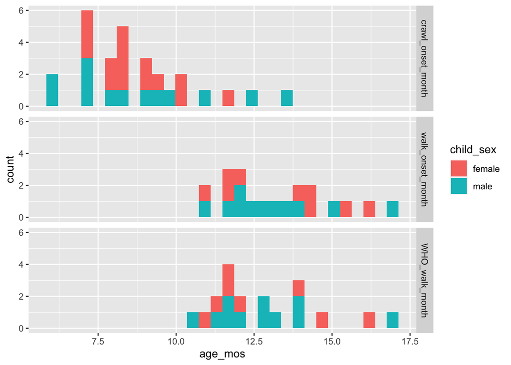

```r
loco_cleaned <- loco_milestones %>%
  dplyr::select(.,
                child_age_grp,
                child_sex,
                WHO_walk_month,
                walk_onset_month,
                crawl_onset_month) %>%
  tidyr::pivot_longer(
    .,
    cols = c('WHO_walk_month', 'walk_onset_month', 'crawl_onset_month'),
    names_to = "milestone",
    values_to = "age_mos"
  )

loco_cleaned %>%
  ggplot(.) +
  aes(x = age_mos, fill = child_sex) +
  geom_histogram() +
  facet_grid(milestone ~ .)
```

## Health

```r
# # Grab the asset_id for the data based on the name
# health_in_name <-
#   stringr::str_detect(play_survey_files$name, 'health')
# health_asset_id <- play_survey_files$asset_id[health_in_name]
#
# # Select and download the data
# health <-
#   databraryapi::read_csv_data_as_df(params$play_survey_session_id, as.numeric(health_asset_id))
#
# # Print the data
# health %>%
#   kableExtra::kbl(.) %>%
#   kableExtra::kable_styling(.,
#                             bootstrap_options = c("striped", "hover", "condensed", "responsive")) %>%
#   kableExtra::scroll_box(width = "800px", height = "300px")
```

## Media

```r
# Grab the asset_id for the data based on the name
media_in_name <-
  stringr::str_detect(play_survey_files$name, 'media')
media_asset_id <- play_survey_files$asset_id[media_in_name]

# Select and download the data
media <-
  databraryapi::read_csv_data_as_df(params$play_survey_session_id, as.numeric(media_asset_id))

# Print the data
media %>%
  kableExtra::kbl(.) %>%
  kableExtra::kable_styling(.,
                            bootstrap_options = c("striped", "hover", "condensed", "responsive")) %>%
  kableExtra::scroll_box(width = "800px", height = "300px")
```

| play_site_id | site_child_id | child_age_grp | child_sex | kobo_form | have_devices | have_tv | have_dvd | have_computer | have_smartphone | have_tablet | have_ed_game | have_game_console | child_used_tv | how_use_tv | child_used_dvd | how_use_dvd | child_use_computer | how_use_computer | child_use_smartphone | how_use_smartphone | child_use_tablet | how_use_tablet | child_use_ed_game | how_use_ed_game | child_use_game_console | how_use_game_console | tv_on_no_watching | use_device_meals | use_device_playtime | … |
| --- | --- | --- | --- | --- | --- | --- | --- | --- | --- | --- | --- | --- | --- | --- | --- | --- | --- | --- | --- | --- | --- | --- | --- | --- | --- | --- | --- | --- | --- | --- |
| PLAY_89941455 | 3 | 12 month | Female | 12_Bilingual_English | TV DVD player Computer Smart phone iPad or other tablet | 1 | 1 | 1 | 1 | 1 | 0 | 0 | Yes | Looks if on. | No | NA | No | NA | No | NA | No | NA | NA | NA | NA | NA | 5 | Not very likely (2) | Neutral (3) | … |
| PLAY_89941534 | 1 | 12 month | Female | 12_Bilingual_Spanish | TV Computadora Smart phone iPad or otras tablet Video juegos (ex. Xbox) | 1 | 0 | 1 | 1 | 1 | 0 | 1 | Sí | Rarely. Parents never put shows for her. | NA | NA | No | NA | No | NA | No | NA | NA | NA | No | NA | 2 | Rara vez (2) | Rara vez (2) | … |
| PLAY_899_232_NODB | 232 | 12 month | Female | 12_English | TV Computer Smart phone iPad or other tablet | 1 | 0 | 1 | 1 | 1 | 0 | 0 | No | NA | NA | NA | No | NA | Yes | In the car. Baby Einstein. | No | NA | NA | NA | NA | NA | 2 | Not very likely (2) | Not very likely (2) | … |
| PLAY_89941894 | 7 | 12 month | Female | 12_English | TV Computer Smart phone | 1 | 0 | 1 | 1 | 0 | 0 | 0 | Yes | Watches whatever TV parents have on but doesn’t control it. | NA | NA | No | NA | Yes | Grabs phone if parents have it lying around to play with. Plays with touch screen. | NA | NA | NA | NA | NA | NA | NA | I never do this (1) | Likely (4) | … |
| PLAY_95442353 | 10 | 12 month | Male | 12_English | TV DVD player Computer Smart phone iPad or other tablet Video game console (Xbox) | 1 | 1 | 1 | 1 | 1 | 0 | 1 | Yes | Watches it | No | NA | No | NA | Yes | To watch videos/listen to music | No | NA | NA | NA | No | NA | 2 | Not very likely (2) | Likely (4) | … |
| PLAY_95441417 | 3 | 12 month | Female | 12_English | TV DVD player Computer Smart phone iPad or other tablet | 1 | 1 | 1 | 1 | 1 | 0 | 0 | No | NA | No | NA | No | NA | No | NA | No | NA | NA | NA | NA | NA | NA | Not very likely (2) | Not very likely (2) | … |
| PLAY_89943207 | 13 | 12 month | Female | 12_English | TV Computer Smart phone iPad or other tablet | 1 | 0 | 1 | 1 | 1 | 0 | 0 | No | NA | NA | NA | No | NA | No | NA | No | NA | NA | NA | NA | NA | 2 | Not very likely (2) | Not very likely (2) | … |
| PLAY_899_226_NODB | 226 | 12 month | Male | 12_English | TV DVD player Computer Smart phone iPad or other tablet | 1 | 1 | 1 | 1 | 1 | 0 | 0 | No | NA | No | NA | No | NA | Yes | FaceTime | Yes | FaceTime | NA | NA | NA | NA | 8 | Likely (4) | Neutral (3) | … |
| PLAY_89938197 | 228 | 12 month | Male | 12_English | TV DVD player Computer Smart phone iPad or other tablet Video game console (Xbox) | 1 | 1 | 1 | 1 | 1 | 0 | 1 | Yes | Plays with remote | No | NA | No | NA | No | NA | No | NA | NA | NA | No | NA | 4 | Not very likely (2) | Neutral (3) | … |
| PLAY_89938485 | 231 | 12 month | Female | 12_English | TV DVD player Computer Smart phone iPad or other tablet | 1 | 1 | 1 | 1 | 1 | 0 | 0 | Yes | A little bit of football, just once. | No | NA | Yes | Just bashed keyboard | Yes | FaceTime | No | NA | NA | NA | NA | NA | 2 | I never do this (1) | Not very likely (2) | … |
| PLAY_95441428 | 4 | 12 month | Female | 12_English | TV Smart phone | 1 | 0 | 0 | 1 | 0 | 0 | 0 | No | NA | NA | NA | NA | NA | Yes | Godfather taught her how to touch ut and make things happen | NA | NA | NA | NA | NA | NA | 2 | Likely (4) | Very likely (5) | … |
| PLAY_89941608 | 5 | 12 month | Female | 12_English | TV Smart phone iPad or other tablet Video game console (Xbox) | 1 | 0 | 0 | 1 | 1 | 0 | 1 | Yes | Baby Einstein during mom work when younger, morning news mom watches | NA | NA | NA | NA | No | NA | No | NA | NA | NA | No | NA | 6 | Not very likely (2) | Likely (4) | … |
| PLAY_95442694 | 11 | 18 month | male | 18_English | TV DVD player Computer Smart phone iPad or other tablet | 1 | 1 | 1 | 1 | 1 | 0 | 0 | Yes | Watch | Yes | Watches | No | NA | Yes | Videos, touching screen, pictures | Yes | Videos pictures | NA | NA | NA | NA | 2.5 | I never do this (1) | Neutral (3) | … |
| PLAY_95442127 | 8 | 18 month | female | 18_English | TV DVD player Computer Smart phone iPad or other tablet Video game console (Xbox) | 1 | 1 | 1 | 1 | 1 | 0 | 1 | Yes | Watches a show | No | NA | No | NA | Yes | Play games with grandparents and video chatting with grandparents | No | NA | NA | NA | No | NA | 4 | Neutral (3) | Likely (4) | … |
| PLAY_98242940 | 3 | 18 month | male | 18_English | TV DVD player Computer Smart phone | 1 | 1 | 1 | 1 | 0 | 0 | 0 | Yes | Watches TV | No | NA | No | NA | Yes | Video call Grandparents | NA | NA | NA | NA | NA | NA | 2 | I never do this (1) | Not very likely (2) | … |
| PLAY_89938196 | 227 | 18 month | female | 18_English | TV Computer Smart phone iPad or other tablet | 1 | 0 | 1 | 1 | 1 | 0 | 0 | Yes | Playing kids songs on YouTube | NA | NA | No | NA | Yes | FaceTime | Yes | Puts on while in high chair when cooking or showering | NA | NA | NA | NA | 24 | Not very likely (2) | Likely (4) | … |
| PLAY_95440510 | 2 | 18 month | female | 18_English | TV DVD player Computer Smart phone iPad or other tablet Video game console (Xbox) | 1 | 1 | 1 | 1 | 1 | 0 | 1 | Yes | 5 min/week while getting nails trimmed | No | NA | No | NA | Yes | NA | No | NA | NA | NA | No | NA | 2 | Likely (4) | Likely (4) | … |
| PLAY_899_232_NODB | 232 | 18 month | male | 18_English | TV DVD player Computer Smart phone iPad or other tablet | 1 | 1 | 1 | 1 | 1 | 0 | 0 | Yes | Movies | No | NA | No | NA | No | NA | Yes | Songs | NA | NA | NA | NA | 1 | I never do this (1) | Likely (4) | … |
| PLAY_89941535 | 4 | 18 month | male | 18_English | TV DVD player Computer Smart phone iPad or other tablet | 1 | 1 | 1 | 1 | 1 | 0 | 0 | Yes | Watches cartoons | No | NA | No | NA | Yes | Watches cartoons, listens to music | No | NA | NA | NA | NA | NA | 0 | Likely (4) | Likely (4) | … |
| PLAY_96643624 | 1 | 18 month | male | 18_English | TV DVD player Computer Smart phone | 1 | 1 | 1 | 1 | 0 | 0 | 0 | Yes | Fake remote in which he can play with and watches cartoons about once a day. | No | NA | No | NA | Yes | Facetime | NA | NA | NA | NA | NA | NA | 3 | Likely (4) | Likely (4) | … |
| PLAY_110344638 | 1 | 18 month | female | 18_English | TV DVD player Computer Smart phone iPad or other tablet | 1 | 1 | 1 | 1 | 1 | 0 | 0 | Yes | Watches | No | NA | No | NA | Yes | Talk on Facetime with grandma, does not play with it | No | NA | NA | NA | NA | NA | NA | Not very likely (2) | Not very likely (2) | … |
| PLAY_89938215 | 229 | 24 month | Female | 24_Bilingual_Spanish | TV Computer Smart phone iPad or other tablet Video game console (Xbox) | 1 | 0 | 1 | 1 | 1 | 0 | 1 | Sí | Music shows | NA | NA | No | NA | Sí | NA | Sí | NA | NA | NA | No | NA | 2 | A menudo (4) | Rara vez (2) | … |
| PLAY_98242292 | 2 | 24 month | female | 24_English | Computer DVD player iPad or other tablet Smart phone TV Video game console (Xbox) | 1 | 1 | 1 | 1 | 1 | 0 | 1 | Yes | Watched like one show in her life | No | NA | No | NA | Yes | Facetime | No | NA | NA | NA | No | NA | 1 | Not very likely (2) | Not very likely (2) | … |
| PLAY_95442353 | 10 | 24 month | female | 24_English | Computer iPad or other tablet Smart phone TV Video game console (Xbox) | 1 | 0 | 1 | 1 | 1 | 0 | 1 | Yes | NA | NA | NA | No | NA | Yes | Facetime/ see pictures | No | NA | NA | NA | No | NA | 3-4 hours | Likely (4) | Not very likely (2) | … |
| PLAY_95441873 | 5 | 24 month | male | 24_English | Computer DVD player iPad or other tablet Smart phone TV | 1 | 1 | 1 | 1 | 1 | 0 | 0 | Yes | Watches TV when sick | No | NA | No | NA | Yes | Pictures | Yes | Pictures | NA | NA | NA | NA | Never | Not very likely (2) | Not very likely (2) | … |
| PLAY_89938236 | 230 | 24 month | male | 24_English | TV Computer Smart phone iPad or other tablet | 1 | 0 | 1 | 1 | 1 | 0 | 0 | No | NA | NA | NA | No | NA | Yes | only once on plane | No | NA | NA | NA | NA | NA | 0 | Neutral (3) | Neutral (3) | … |
| PLAY_89941800 | 2 | 24 month | male | 24_English | Computer Smart phone iPad or other tablet | 0 | 0 | 1 | 1 | 1 | 0 | 0 | NA | NA | NA | NA | No | NA | Yes | To watch videos | Yes | Plays games. | NA | NA | NA | NA | NA | Not very likely (2) | Likely (4) | … |
| PLAY_89941808 | 6 | 24 month | male | 24_English | TV DVD player Computer Smart phone iPad or other tablet Educational game (Leapster) Video game console (Xbox) | 1 | 1 | 1 | 1 | 1 | 1 | 1 | Yes | Watched a little, use the remote occasionally | No | NA | No | NA | Yes | Plays child games | No | NA | Yes | Identify words to pictures | No | NA | 12 | Not very likely (2) | Neutral (3) | … |
| PLAY_95441873 | 5 | 24 month | male | 24_English | TV DVD player Computer Smart phone iPad or other tablet | 1 | 1 | 1 | 1 | 1 | 0 | 0 | Yes | To watch it | No | NA | No | NA | Yes | To take pictures | Yes | Pictures | NA | NA | NA | NA | 0 | Not very likely (2) | Not very likely (2) | … |
| PLAY_89943530 | 14 | 24 month | male | 24_English | Computer Smart phone | 0 | 0 | 1 | 1 | 0 | 0 | 0 | NA | NA | NA | NA | Yes | Went to library once and played with mouse and keyboard | Yes | Looks at pictures and Skypes/Facetimed family | NA | NA | NA | NA | NA | NA | NA | Likely (4) | Likely (4) | … |

Do some clean-up to summarize some of the findings.

```r
media %>%
  dplyr::select(., child_age_grp, have_tv, child_used_tv) %>%
  dplyr::filter(., !is.na(child_used_tv)) %>%
  dplyr::mutate(., child_used_tv = recode(child_used_tv, 'Sí' = 'Yes')) %>%
  dplyr::group_by(child_age_grp) %>%
  dplyr::summarise(homes_w_tv = sum(have_tv),
                   children_use_tv = sum(child_used_tv == "Yes")) %>%
  kableExtra::kbl(.) %>%
  kableExtra::kable_styling(.,
                            bootstrap_options = c("striped", "hover", "condensed", "responsive")) %>%
  kableExtra::scroll_box(width = "800px", height = "250px")
```

| child_age_grp | homes_w_tv | children_use_tv |
| --- | --- | --- |
| 12 month | 12 | 7 |
| 18 month | 9 | 9 |
| 24 month | 7 | 6 |

# Clean-up

Log out of Databrary.

```r
databraryapi::logout_db()
```

```
## Logout Successful.
```

```
## [1] TRUE
```